| Tittle: Exercise3: Analysis |
| --- |

Author: Elmeri Santala

**Data wrangling** I read the data from URL web page, joined the two data sets using the variables “school”, “sex”, “age”, “address”, “famsize”, “Pstatus”, “Medu”, “Fedu”, “Mjob”, “Fjob”, “reason”, “nursery”,“internet” as (student) identifiers. I Kept only the students present in both data sets. Then, I took the average of the answers related to weekday and weekend alcohol consumption to create a new column ‘alc_use’ to the joined data. Then I used ‘alc_use’ to create a new logical column ‘high_use’ which is TRUE for students for which ‘alc_use’ is greater than 2 (the range is: from 1 - very low to 5 - very high).

Code for data wrangling: https://github.com/elmeris/IODS-project/blob/master/data/create_alc.R

**Reading data**

```r
alc <- read.csv("~/IODS-project/data/alc.csv")
head(alc)
```

```
##   school sex age address famsize Pstatus Medu Fedu     Mjob     Fjob
## 1     GP   F  18       U     GT3       A    4    4  at_home  teacher
## 2     GP   F  17       U     GT3       T    1    1  at_home    other
## 3     GP   F  15       U     LE3       T    1    1  at_home    other
## 4     GP   F  15       U     GT3       T    4    2   health services
## 5     GP   F  16       U     GT3       T    3    3    other    other
## 6     GP   M  16       U     LE3       T    4    3 services    other
##       reason nursery internet guardian traveltime studytime failures
## 1     course     yes       no   mother          2         2        0
## 2     course      no      yes   father          1         2        0
## 3      other     yes      yes   mother          1         2        2
## 4       home     yes      yes   mother          1         3        0
## 5       home     yes       no   father          1         2        0
## 6 reputation     yes      yes   mother          1         2        0
##   schoolsup famsup paid activities higher romantic famrel freetime goout
## 1       yes     no   no         no    yes       no      4        3     4
## 2        no    yes   no         no    yes       no      5        3     3
## 3       yes     no  yes         no    yes       no      4        3     2
## 4        no    yes  yes        yes    yes      yes      3        2     2
## 5        no    yes  yes         no    yes       no      4        3     2
## 6        no    yes  yes        yes    yes       no      5        4     2
##   Dalc Walc health absences G1 G2 G3 alc_use high_use
## 1    1    1      3        5  2  8  8     1.0    FALSE
## 2    1    1      3        3  7  8  8     1.0    FALSE
## 3    2    3      3        8 10 10 11     2.5     TRUE
## 4    1    1      5        1 14 14 14     1.0    FALSE
## 5    1    2      5        2  8 12 12     1.5    FALSE
## 6    1    2      5        8 14 14 14     1.5    FALSE
```

```r
colnames(alc)
```

```
##  [1] "school"     "sex"        "age"        "address"    "famsize"
##  [6] "Pstatus"    "Medu"       "Fedu"       "Mjob"       "Fjob"
## [11] "reason"     "nursery"    "internet"   "guardian"   "traveltime"
## [16] "studytime"  "failures"   "schoolsup"  "famsup"     "paid"
## [21] "activities" "higher"     "romantic"   "famrel"     "freetime"
## [26] "goout"      "Dalc"       "Walc"       "health"     "absences"
## [31] "G1"         "G2"         "G3"         "alc_use"    "high_use"
```

**My analysis from data**

My hypotesis are: 1) Men consume more alcohol 2) Students with lower grades consume more alcohol 3) Students with more absences consume more alcohol 4) Older students consume more alcohol

Lets find out!

```r
library(tidyr); library(dplyr); library(ggplot2)
glimpse(alc)
```

```
## Observations: 382
## Variables: 35
## $ school     <fct> GP, GP, GP, GP, GP, GP, GP, GP, GP, GP, GP, GP, GP, G…
## $ sex        <fct> F, F, F, F, F, M, M, F, M, M, F, F, M, M, M, F, F, F,…
## $ age        <int> 18, 17, 15, 15, 16, 16, 16, 17, 15, 15, 15, 15, 15, 1…
## $ address    <fct> U, U, U, U, U, U, U, U, U, U, U, U, U, U, U, U, U, U,…
## $ famsize    <fct> GT3, GT3, LE3, GT3, GT3, LE3, LE3, GT3, LE3, GT3, GT3…
## $ Pstatus    <fct> A, T, T, T, T, T, T, A, A, T, T, T, T, T, A, T, T, T,…
## $ Medu       <int> 4, 1, 1, 4, 3, 4, 2, 4, 3, 3, 4, 2, 4, 4, 2, 4, 4, 3,…
## $ Fedu       <int> 4, 1, 1, 2, 3, 3, 2, 4, 2, 4, 4, 1, 4, 3, 2, 4, 4, 3,…
## $ Mjob       <fct> at_home, at_home, at_home, health, other, services, o…
## $ Fjob       <fct> teacher, other, other, services, other, other, other,…
## $ reason     <fct> course, course, other, home, home, reputation, home, …
## $ nursery    <fct> yes, no, yes, yes, yes, yes, yes, yes, yes, yes, yes,…
## $ internet   <fct> no, yes, yes, yes, no, yes, yes, no, yes, yes, yes, y…
```

[output cut: 22 more lines]

```r
gather(alc) %>% glimpse
```

```
## Observations: 13,370
## Variables: 2
## $ key   <chr> "school", "school", "school", "school", "school", "school"…
## $ value <chr> "GP", "GP", "GP", "GP", "GP", "GP", "GP", "GP", "GP", "GP"…
```

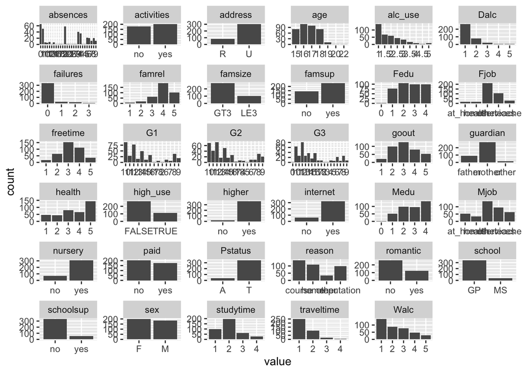

```r
gather(alc) %>% ggplot(aes(value)) + facet_wrap("key", scales = "free") + geom_bar()
```

```r
library(dplyr); library(ggplot2)
```

```r
alc %>% group_by(sex, high_use) %>% summarise(count = n(), mean_grade = mean(G3))
```

```
## # A tibble: 4 x 4
## # Groups:   sex [2]
##   sex   high_use count mean_grade
##   <fct> <lgl>    <int>      <dbl>
## 1 F     FALSE      156       11.4
## 2 F     TRUE        42       11.7
## 3 M     FALSE      112       12.2
## 4 M     TRUE        72       10.3
```

As we can see in the table above that it seems that my first hypothesis was maybe right because men consume more alcohol than women. Yet I dont know is this difference statistically significant or not.

```r
g1 <- ggplot(alc, aes(x = high_use, y = G3, col = sex))
```

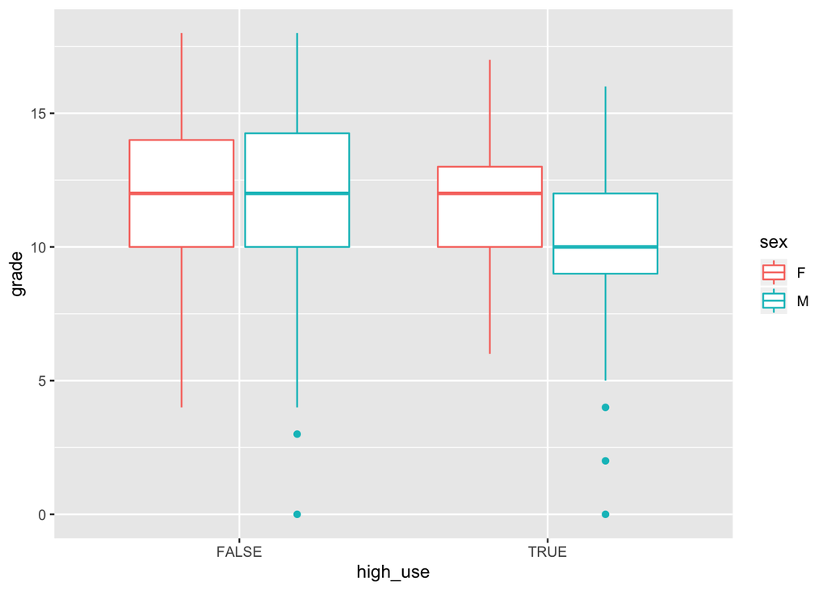

```r
g1 + geom_boxplot() + ylab("grade")
```

As the boxplot above shows the students with lower final grade consume more alcohol. This means my second hypothesis was maybe right. Yet I dont know is this difference statistically significant or not.

```r
g2 <- ggplot(alc, aes(x = high_use, y = absences, col = sex))
```

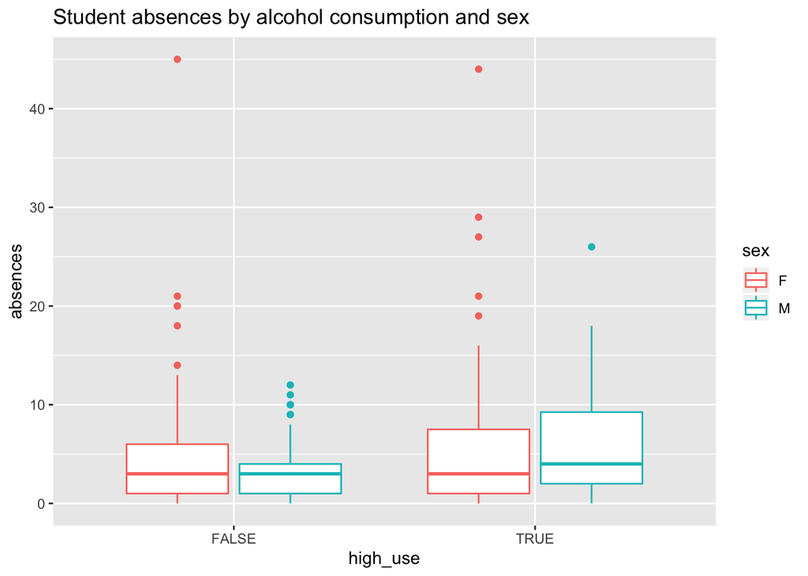

```r
g2 + geom_boxplot() + ggtitle("Student absences by alcohol consumption and sex")
```

As the boxplot above shows the students with more absences consume more alcohol. This means my third hypothesis was maybe right. Yet I dont know is this difference statistically significant or not.

```r
g3 <- ggplot(alc, aes(x = high_use, y = age, col = sex))
```

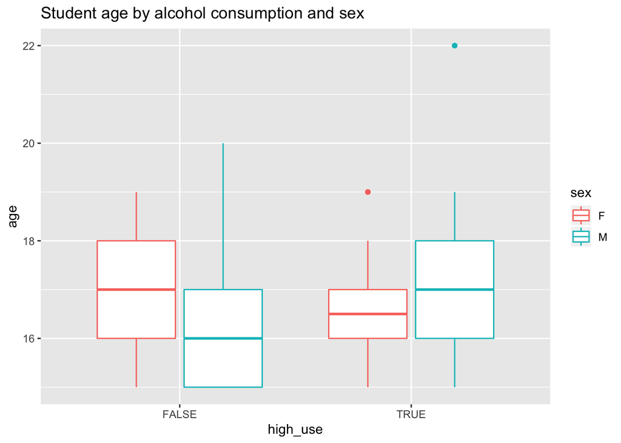

```r
g3 + geom_boxplot() + ggtitle("Student age by alcohol consumption and sex")
```

```r
m <- glm(high_use ~ age + G3 + absences + sex, data = alc, family = "binomial")
```

```r
summary(m)
```

```
##
## Call:
## glm(formula = high_use ~ age + G3 + absences + sex, family = "binomial",
##     data = alc)
##
## Deviance Residuals:
##     Min       1Q   Median       3Q      Max
## -2.2729  -0.8326  -0.6292   1.0442   2.1190
##
## Coefficients:
##             Estimate Std. Error z value Pr(>|z|)
## (Intercept) -3.38339    1.84796  -1.831 0.067120 .
## age          0.13985    0.10328   1.354 0.175690
## G3          -0.06631    0.03624  -1.830 0.067277 .
## absences     0.08964    0.02309   3.882 0.000104 ***
## sexM         0.98580    0.24184   4.076 4.58e-05 ***
## ---
## Signif. codes:  0 '***' 0.001 '**' 0.01 '*' 0.05 '.' 0.1 ' ' 1
##
## (Dispersion parameter for binomial family taken to be 1)
##
##     Null deviance: 465.68  on 381  degrees of freedom
## Residual deviance: 423.66  on 377  degrees of freedom
## AIC: 433.66
##
## Number of Fisher Scoring iterations: 4
```

```r
coef(m)
```

```
## (Intercept)         age          G3    absences        sexM
## -3.38338833  0.13985344 -0.06630516  0.08963638  0.98580237
```

```r
m <- glm(high_use ~ age + G3 + absences + sex, data = alc, family = "binomial")
```

```r
OR <- coef(m) %>% exp
```

```r
CI <- confint(m) %>% exp
cbind(OR, CI)
```

```
##                     OR        2.5 %   97.5 %
## (Intercept) 0.03393229 0.0008683319 1.237502
## age         1.15010522 0.9401979286 1.410759
## G3          0.93584524 0.8710385897 1.004426
## absences    1.09377649 1.0474354900 1.146836
## sexM        2.67996134 1.6781593816 4.338864
```

The fitted logistic regression model demonstrate that two of my chosen variables: absences and sex are statistically significant in relation to alcohol consumption. These variables have a p-value of <0.001.

The two other variables: age and final grade did not show statistical significance in relation to alcohol consumption.

Sex: Odds ratio shows us that the male students have higher alcohol consumption 2.7 times more likely than female students. (95% Cl 1.68-4.34)

**Prediction of the probability of high_use**

```r
probabilities <- predict(m, type = "response")
```

```r
alc <- mutate(alc, probability = probabilities)
```

```r
alc <- mutate(alc, prediction = probability > 0.5)
```

```r
table(high_use = alc$high_use, prediction = alc$prediction)
```

```
##         prediction
## high_use FALSE TRUE
##    FALSE   255   13
##    TRUE     84   30
```

```r
table(high_use = alc$high_use, prediction = alc$prediction) %>% prop.table %>% addmargins
```

```
##         prediction
## high_use      FALSE       TRUE        Sum
##    FALSE 0.66753927 0.03403141 0.70157068
##    TRUE  0.21989529 0.07853403 0.29842932
##    Sum   0.88743455 0.11256545 1.00000000
```

These tables shows us that in 339 false (low alcohol use) predictions 255 were really false, thats about 75%, and in 43 true (high alcohol use) predictions 30 were really true, thats about 70%.

**Visualizing the prediction of the probability of high_use**

```r
library(dplyr); library(ggplot2)
```

```r
g <- ggplot(alc, aes(x = probability, y = high_use, col = prediction))
```

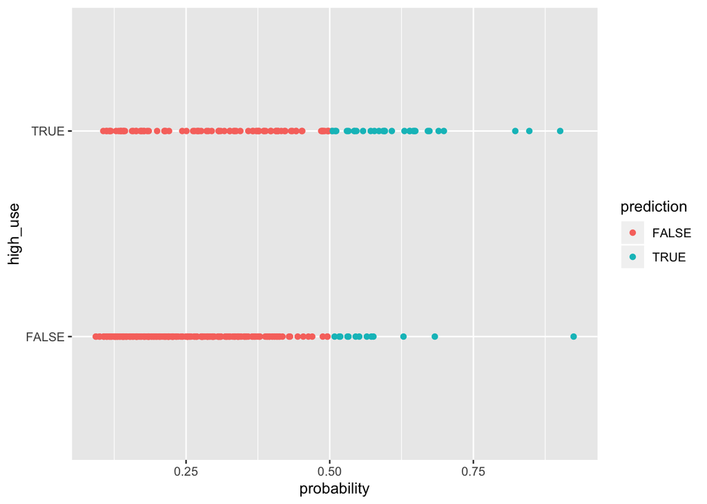

```r
g + geom_point()
```

This plot shows us that the prediction of correct classification is quite good, but there is some misclassifications with this model.